# Process Stats Game pilot data

Read in data and load packages.

```r
library(flextable)
```

## How did participants perform?

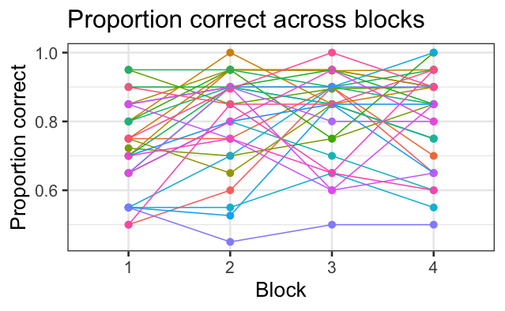

```r
ggplot(p.agg, aes(x = block, y = meanAcc, color = Participant.Public.ID, group = Participant.Public.ID)) +
  geom_point(size= 2.5) + geom_line() +
  theme_bw(18) +
  ylab("Proportion correct") +
  xlab("Block") +
  ggtitle("Proportion correct across blocks") +
  theme(legend.position = "none")
# block means
sum.dat %>%
  group_by(block) %>%
  summarise(meanAcc = mean(Correct))
```

| block | meanAcc |
| --- | --- |
| 1 | 0.7274247 |
| 2 | 0.8110368 |
| 3 | 0.8207705 |
| 4 | 0.8066667 |

| block <fctr> | meanAcc <dbl> |  |  |  |
| --- | --- | --- | --- | --- |
| 1 | 0.7274247 |  |  |  |
| 2 | 0.8110368 |  |  |  |
| 3 | 0.8207705 |  |  |  |
| 4 | 0.8066667 |  |  |  |

4 rows

Slopes for individual participants are fairly mixed with a few showing learning and others not. As can be seen from the printed tibble is that accuracy during block 1 is around 72%. This increased for block 2 and remains stable. This indicates that participants are learning this fairly early on.

## What array were participants responding to?

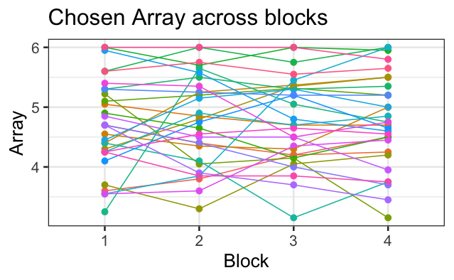

```r
array.dat<- sum.dat %>%
  mutate(array= as.numeric(cut(Reaction.Time, breaks= c(0,2000,4000,6000,8000,10000,Inf), labels = c("1","2","3","4","5","6"))))
# mean array
array.agg <- array.dat %>%
  group_by(Participant.Public.ID, block) %>%
  summarise(meanArray = mean(array),
            meanAcc = mean(Correct))
# visualize
ggplot(array.agg, aes(x = block, y = meanArray, color = Participant.Public.ID, group = Participant.Public.ID)) +
  geom_point(size= 2.5) + geom_line() +
  theme_bw(18) +
  ylab("Array") +
  xlab("Block") +
  ggtitle("Chosen Array across blocks") +
  theme(legend.position = "none")
```

```r
# block means
array.dat %>%
  group_by(block) %>%
  summarise(meanArray = mean(array))
```

| block | meanArray |
| --- | --- |
| 1 | 4.697324 |
| 2 | 4.762542 |
| 3 | 4.755444 |
| 4 | 4.755000 |

| block <fctr> | meanArray <dbl> |  |  |  |
| --- | --- | --- | --- | --- |
| 1 | 4.697324 |  |  |  |
| 2 | 4.762542 |  |  |  |
| 3 | 4.755444 |  |  |  |
| 4 | 4.755000 |  |  |  |

4 rows

Slopes for individual participants are fairly mixed with some choosing later arrays in the second half while others are not. From the printed tibble there isn’t much of a change in chosen array.

## Planned analysis

We plan to exclude those who score more than 90% correct in block 1.

### Hypothesis 1

For hypothesis 1, we state: *In the training task, we predict that responses in the first block of training will tend to be non-optimal, made when the array size is small enough to make an error likely. The array index at which a response is made for all subjects will be compared with a value of 5 (corresponding to N = 160 and power = .85 - see Figure 2), using a directional one-sample t-tests, with the prediction that most participants will make responses at an earlier array index than this.*

```r
h1.test <- array.agg %>%
  filter(block==1,
         meanAcc < .90)
t.test(h1.test$meanArray, mu= 5, alternative = "less")
```

```
    One Sample t-test

data:  h1.test$meanArray
t = -2.963, df = 25, p-value = 0.003299
alternative hypothesis: true mean is less than 5
95 percent confidence interval:
     -Inf 4.820373
sample estimates:
mean of x
 4.575855
```

Out of the 30 participants, 4 were removed due to having greater than 89% accuracy during block 1. The *t*-test indicates that the array during block 1 is statistically different from 5.

### Hypothesis 2

For hypothesis 2, we state: *Overconfidence in small samples will decline with training. This prediction will be tested by assessing whether array index at the point of selection is higher for the last than the first block of the training session, using a one-tailed t-test. In addition, it is anticipated that within each block there will be a positive correlation between accuracy and array index, indicating that subjects use the additional information in larger sample sizes to guide their responding.*

```r
h2.test <- array.agg %>%
  filter(block==1 | block==4,
         Participant.Public.ID %in% h1.test$Participant.Public.ID)
# means
aggregate(FUN= mean, data= h2.test, meanArray~ block)
```

| block | meanArray |
| --- | --- |
| 1 | 4.575855 |
| 4 | 4.634615 |

| block <fctr> | meanArray <dbl> |  |  |  |
| --- | --- | --- | --- | --- |
| 1 | 4.575855 |  |  |  |
| 4 | 4.634615 |  |  |  |

2 rows

```r
# compare blocks
t.test(h2.test$meanArray~h2.test$block, paired= TRUE, alternative= "greater")
```

```
    Paired t-test

data:  h2.test$meanArray by h2.test$block
t = -0.29832, df = 25, p-value = 0.616
alternative hypothesis: true difference in means is greater than 0
95 percent confidence interval:
 -0.3952209        Inf
sample estimates:
mean of the differences
            -0.05876068
```

Regarding the comparisons across blocks, there is a subtle increase in the array choice. This is not significant in hypothesis test.

## Accuracy analysis

(Added by Dorothy). Although blocks have not increased, it does look as if increase in accuracy is significant. This appears to be a more sensitive way of measuring learning, even though it links less well to our specific hypothesis.

```r
hx.test <- array.agg %>%
  filter(block==1 | block==4,
         Participant.Public.ID %in% h1.test$Participant.Public.ID)
# means
aggregate(FUN= mean, data= hx.test, meanAcc~ block)
```

| block | meanAcc |
| --- | --- |
| 1 | 0.6970085 |
| 4 | 0.7942308 |

| block <fctr> | meanAcc <dbl> |  |  |  |
| --- | --- | --- | --- | --- |
| 1 | 0.6970085 |  |  |  |
| 4 | 0.7942308 |  |  |  |

2 rows

```r
# compare blocks
t.test(hx.test$meanAcc~hx.test$block, paired= TRUE, alternative= "less")
```

```
    Paired t-test

data:  hx.test$meanAcc by hx.test$block
t = -3.7775, df = 25, p-value = 0.0004377
alternative hypothesis: true difference in means is less than 0
95 percent confidence interval:
        -Inf -0.05325902
sample estimates:
mean of the differences
            -0.09722222
```

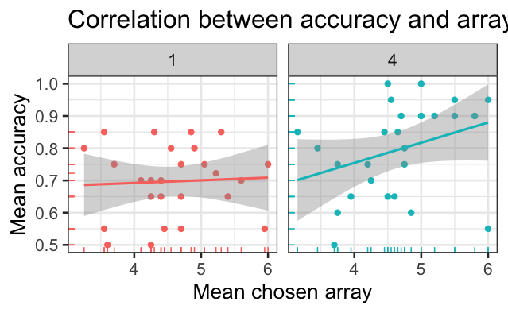

```r
# plot
ggplot(h2.test, aes(x=meanArray, y=meanAcc, color=block)) +
  geom_point(size= 2) +
  geom_rug() +
  geom_smooth(method= lm) +
  facet_wrap(~block) + theme_bw(18) + theme(legend.position = "none") +
  ggtitle("Correlation between accuracy and array") +
  xlab("Mean chosen array") +
  ylab("Mean accuracy")
```

```r
# correlation coefficients
# block 1
cor(h2.test[h2.test$block==1,]$meanAcc, h2.test[h2.test$block==1,]$meanArray, method = "spearman")
```

```
[1] 0.09507634
```

```r
# block 4
cor(h2.test[h2.test$block==4,]$meanAcc, h2.test[h2.test$block==4,]$meanArray, method = "spearman")
```

```
[1] 0.4062081
```

We start to see evidene of a correlation between array and accuracy in block four that isn’t present in block 1.

## How much bonus payment did we give?

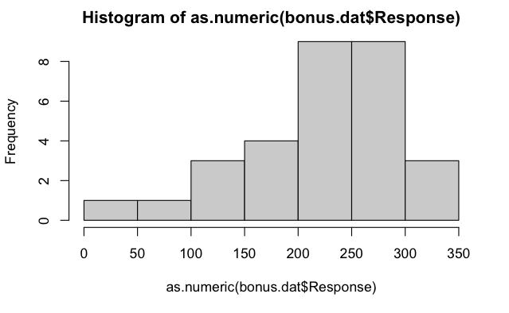

```r
# filter
bonus.dat <- all.dat %>%
  filter(Trial.Number== "bonusPayment")
# plot
hist(as.numeric(bonus.dat$Response))
```

```r
# mean payment
mean(as.numeric(bonus.dat$Response))
```

```
[1] 220.0667
```

The mean bonus payment made was 220.0666667. The total bonus payment made was 6602. As shown in the histogram people are getting the hang.

## What startegies did participants employ?

Here, participants were asked *Did you change how you approached the task? Please let us know if you adopted any specific strategy to guide your response?*

*NOTE*. Only 26 received the follow up questionnaire due to an issue in Gorilla. This is now fixed.

```r
strat.dat <- read.csv("./Data/data_exp_53470-v4_questionnaire-lo83.csv", na.strings = c("NA", ""))
# subjective improvement
improve <- strat.dat %>%
  filter(Question.Key== "better.over.time")
# counts
table(improve$Response)
```

```
    No Unsure    Yes
     1      4     21
```

```r
# filter
strat.dat <- strat.dat %>%
  filter(Question.Key== "approach.feedback")
# list
print(strat.dat$Response)
```

```
 [1] "Always wait for more evidence no matter how obvious it looks at the start."
 [2] "No specific strategy "
 [3] "no"
 [4] "no"
 [5] "If the lines were far apart with small sample size, but got very close I would always wait until later to see if the erlier seperation was repeated again. If multiple sample sizes showed the same distribution of averages back to back I would often commit too an answer."
 [6] "I stated trying to answer earlier but realised this couldnt always be predicted. "
 [7] "Ended up using second to last data point as my guide for an answer"
 [8] "I tried to wait until I was more sure that the data wasn't going to change in any significant way before making a decision"
 [9] "The better I understood the easier it was to make a decision."
[10] "I would look in detail and see which colour stood out and saw the most of."
[11] "I waited for more data to confirm my results. In addition, I noticed if the pink line was above the blue at the start, they were more likely to be equal."
[12] "I focused hard"
[13] "After a while I started anticipating the significance after the 3rd image had been showed and made my decisions based on how much potential change I felt could occur between the second to last and last number of participants."
[14] "i started to look more at trends between the distributions e.g if red was higher on the first 2 then more likely blue = red and so on"
[15] "I started off looking at the lines but ended up trying to guess the number of dots"
[16] "I approached the task hesitantly and waited until i could see most of the bars before making a decision, I used estimation rather than looking at the numbers."
[17] "Mainly seeing if there is a trend in the beginning"
[18] "Waiting for more evidence before answering (unless data was very clear)"
[19] "at the beginning i tried to follow the pattern up until the 80 mark and decide then, but at the end i just copied what was on the largest sample result"
[20] "i started looking more at the gaps and tried to average them out to see which line was higher."
[21] "Towards the end of the task I was waiting longer for more evidence to appear before making a judgement, focussing on accuracy over the potential extra 2 points"
[22] "After guessing quite a few wrong with the first 3 data sets I mostly waited till the last or penultimate part of data to ensure I was right"
[23] "i decided it was better not to rush into choosing the answer. It was best to wait until you had more information. "
[24] "I started to look at patterns rather than basing my estimate on the earliest plots."
[25] "I looked to see if the gap was changing between trials"
[26] "waited longer to respond as the study went on "
```

21 participants reported that they had improved over time, with 1 saying they did not and 4 saying they were unsure. As we can see from the qualitative questions a few participants didn’t employ a strategy.

The good news is that a few people learned that later arrays produced more reliable results.